# LandUse_Markdown

Geting Trend from Existing Land Use in DC AREA

We decided to use the dataset of existing land use in the DC area. It records the land used for now and what the land used before. We can make a comparison and find out the interesting trend behind the redevelopment.

Source data: https://opendata.dc.gov/datasets/existing-land-use?geometry=-78.003%2C38.707%2C-76.026%2C39.081

Analysis steps 1.) Some columns we had no use for, so we decided to drop those from the dataset we were looking at. The columns we kept were: Ward_ID, LU_CODE, OLD_LU_CD, SHAPE_Length,SHAPE_Area Columns Along with dropping some columns we then found it necessary to Change Column name and code name in LU_CODE and OLD_LU_CODE for each column we did keep.

Now that the data set is cleaned and renamed 'Land_use_cleaned.csv' (previously known as Existing_Land_Use.csv) we can begin to examine the different facilities within the land use dataset. Results:

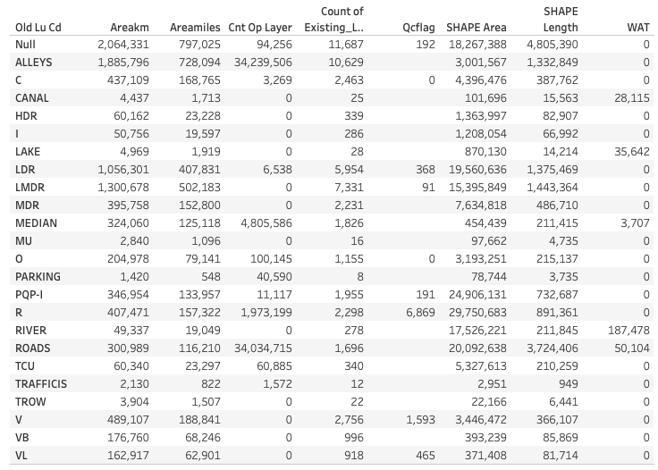

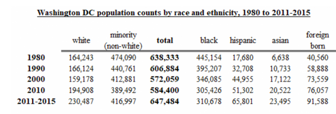

Data Note: Racial and ethnic categories in the table and the animations are exclusive, e.g. white alone (non-hispanic). A small category for “some other race” is not shown. Totals may not sum to 100% due to rounding. Data is compiled via authors’ calculations from decennial census data (1980-2010) spatially adjusted to 2010 census tract boundaries via Brown University’s Longitudinal Tract Database. 2011 to 2015 data is from the American Communities Survey. The authors thank Eli Knaap, PhD of the Center for Geospatial Sciences at the University of California, Riverside for his work in developing the dataset.

2.) Getting trends in different wards When attempting to gain information form the data frame using the current state of land use within each ward, we examined WARD_ID, Land_use_code/Old_Land_use_code, Num_facilities. By doing so we could now break down our map into the eight wards so we could examine for what was on the land and when did the last change occur.

[figure not shown]

[figure not shown]